# Practice: Grammar Of Graphics With ggplot2

# Part 4: Labels And Theme

Add labels.

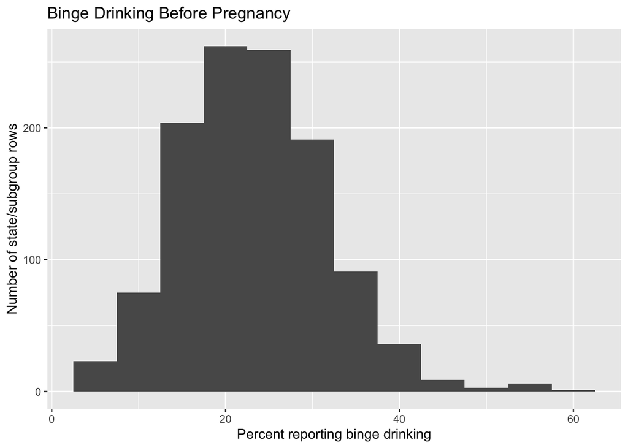

```r
p4 <- p3 +
  labs(
    title = "Binge Drinking Before Pregnancy",
    x = "Percent reporting binge drinking",
    y = "Number of state/subgroup rows"
  )

p4
```

Add a theme.

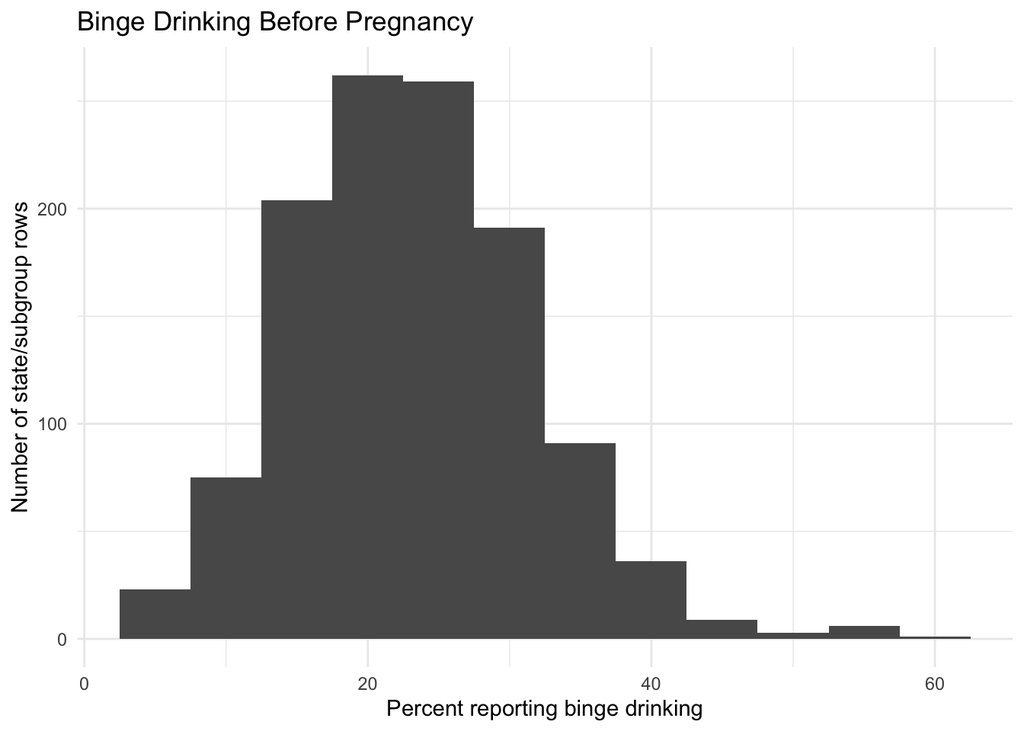

```r
p5 <- p4 +
  theme_minimal()

p5
```